# LAB 4: Text clustering

```python
!pip install -q spacy[cuda11x] sentence-transformers colorcet
!pip install -q https://github.com/explosion/spacy-models/releases/download/en_core_web_lg-3.7.1/en_core_web_lg-3.7.1-py3-none-any.whl
```

```python
from collections import Counter

import colorcet as cc
import matplotlib.pyplot as plt
import numpy as np
import pandas as pd
import spacy
from bokeh.layouts import column
from bokeh.plotting import figure, output_notebook, show
from bokeh.transform import factor_cmap, linear_cmap
from cytoolz import concat, identity
from sentence_transformers import SentenceTransformer
from sklearn.cluster import HDBSCAN
from sklearn.decomposition import TruncatedSVD
from sklearn.feature_extraction.text import TfidfVectorizer
from sklearn.manifold import TSNE
from tqdm.auto import tqdm

output_notebook(hide_banner=True)
tqdm.pandas()
pd.options.mode.copy_on_write = True
```

## Data preparation

Before doing any analysis, we'll neeed to get the data arranged. First load the dataframe and pull out the reviews for the hotel property we're interested in. For demo purposes, I'll just look at sub-sample of the reviews (to save processing time). You should use a larger sample or, ideally, the full set of reviews for your hotel.

```python
df = pd.read_parquet("../lab-02/hotel_review.parquet")
df['review_text'] = df['title'] + " " + df['text']
hotel = df.query('offering_id == 93520').sample(500, random_state=42)
```

Next we'll divide the reviews into sentences using spacy's `sentencizer` module. We also want to keep track of which review each sentences came from and what the overall rating was (for later analysis). By default, the spacy `pipe` function takes strings and produces spacy docs:

[output not shown]

If we set the `as_tuples` option, though, it `pipe` expects pairs of a string and some arbirtary metadata and it produces pairs of spacy docs and metadata. We'll want to keep track of two pieces of metadata--which review the sentence came from and what that review's star rating was--so we've got:

```
(text, (review_id, rating)) -> (doc, (review_id, rating))
```

```python
sentence_splitter = spacy.blank("en")
sentence_splitter.add_pipe("sentencizer")

docs_with_metadata = (
    (row.review_text, (row.Index, row.overall))
    for row in hotel[["review_text", "overall"]].itertuples()
)

sents = pd.DataFrame(
    {"text": s.orth_, "review_id": id, "rating": overall}
    for doc, (id, overall) in sentence_splitter.pipe(docs_with_metadata, as_tuples=True)
    for s in doc.sents
)
```

The results is a dataframe the lists the text of individual sentences, the index value of the review they came from, and the overall star rating associated with the review:

```python
sents
```

|  | text | review_id | rating |
| --- | --- | --- | --- |
| 0 | “ΑΞΙΖΕ ΤΑ ΧΡΗΜΑΤΑ ΤΟΥ ΣΕ ΚΑΘΕ ΠΕΡΙΠΤΩΣΗ!” | 108308 | 4.0 |
| 1 | Η τοποθεσία του ξενοδοχείου εξαιρετική!!!! | 108308 | 4.0 |
| 2 | Κοντά σε όλα! | 108308 | 4.0 |
| 3 | Καθαρό, φροντισμένο και το σέρβις απ'το προσωπ... | 108308 | 4.0 |
| 4 | Επισημαίνω την Elizabeth στην ρεσεψιον που είν... | 108308 | 4.0 |
| ... | ... | ... | ... |
| 4205 | The location of the hotel is amazing. | 74878 | 4.0 |
| 4206 | You are right in the middle of everything. | 74878 | 4.0 |
| 4207 | Look one way down the street and there is Time... | 74878 | 4.0 |
| 4208 | We had a wonderful stay at Park Central and wi... | 74878 | 4.0 |
| 4209 | I have recommended this property to many of my... | 74878 | 4.0 |

4210 rows × 3 columns

If we want to know the context of any sentence, we can retrieve the original review using its id:

```python
hotel.loc[74878]['review_text']
```

```
'“Loved It!!! Our second stay” My first time at this hotel was in July 2008. My husband, my kids and I were starting our vacation with 4 days at the Park Central. Unfortunately, we had to check out the next morning and go home because of a death in the family. The next summer, we decided to go back …
```

## Vectorization

Before we can cluster sentences, we first need to convert them vectors the reflect their meaning, with the goal that cosine similarity between the vectors correlates with semantic similarity. We'll try three methods: Latent Semantic Analysis, static embeddings (GloVe vectors), and sentence transformers (SBERT).

### Latent semantic analysis

One of the earliest methods for constructing semantic vectors, LSA uses Principal Components Analysis to find a low-dimensional representation for the document-term matrix. Actually, we'll technically cheat a bit by skipping the preprocessing steps that are part of PCA and just use the fast and efficient SVD.

For more details about this, see:

- [scikit-learn user's guide](https://scikit-learn.org/stable/modules/decomposition.html#truncated-singular-value-decomposition-and-latent-semantic-analysis)
- [Müller & Guido](https://learning.oreilly.com/library/view/introduction-to-machine/9781449369880/) sections 3.4.1 and 7.5
- [Albrecht et al](https://learning.oreilly.com/library/view/blueprints-for-text/9781492074076/) chapters 5 and 10.

```python
mwt = spacy.load('../lab-02/mwt')
sents['tokenized'] = [[t.norm_ for t in doc if not t.is_space] for doc in mwt.pipe(tqdm(sents['text']))]
```

First step is to construct the document-term matrix. Setting `analyzer=identity` disables [**TfidfVectorizer**](https://scikit-learn.org/stable/modules/generated/sklearn.feature_extraction.text.TfidfVectorizer.html)'s internal tokenizer. *TfidfVectorizer* has lots of flags you can set to change its behavior. You might try playing with the values of `min_df`, `max_df`, `use_idf`, `smooth_idf`, `sublinear_tf`, and `binary`.

The only parameter for [**TruncatedSVD**](https://scikit-learn.org/stable/modules/generated/sklearn.feature_extraction.text.TfidfVectorizer.html) is `n_components`. This determines the number of latent semantic dimensions in our final result.

```python
NDIM = 25

vectorizer = TfidfVectorizer(analyzer=identity)
dtm = vectorizer.fit_transform(sents['tokenized'])
lsa_vectors = TruncatedSVD(n_components=NDIM).fit_transform(dtm)
lsa_vectors.shape
```

```
(4210, 25)
```

### Static embeddings

Here we'll use spacy's [fasttext vectors](https://github.com/explosion/spacy-vectors-builder) which are distributed as part of the en_core_web_lg model. For this kind of model, all the important choices are made when the vectors are trained so we don't have any control over them beyond choosing which set of vectors to use. The vectors included with spacy are based on general English text and are approriate for a lot of applications. If we were working with a specialized genre (e.g., scientific articles) we could use (or build) a set of vectors for that specific application. For now, we'll stick with the defaults.

See [Albrecht et al](https://learning.oreilly.com/library/view/blueprints-for-text/9781492074076/) chapter 10 for more.

```python
nlp = spacy.load(
    "en_core_web_lg",
    exclude=["attribute_ruler", "tagger", "parser", "lemmatizer", "ner"],
)
```

```python
full_spacy_vectors = np.array([s.vector for s in nlp.pipe(tqdm(sents['text']))])
full_spacy_vectors.shape
```

```
(4210, 300)
```

Spacy's vectors have 300 dimensions. This is way more than we need to capture patterns in only ~4,000 sentences and their large size will make the nexts steps much more expensive. So before continuing, we'll use **TruncatedSVD** again to reduce them down to the same number of dimensions we used for LSA up above:

```python
spacy_vectors = TruncatedSVD(n_components=NDIM).fit_transform(full_spacy_vectors)
spacy_vectors.shape
```

```
(4210, 25)
```

### Contextual embeddings

Static embeddings always map a word to the same vector regardless of how it's being used in a sentence. Contextual embeddings on the other hand take sentence context into account. We'll use one of the [SBERT models](https://www.sbert.net), which are transformers trained specifically for computing semantic distance between sentences.

Like static embeddings, all the of the choices for contextual embeddings are made at the time the model is constructed. The only choice we can make is selecting which model to use. There is a list of SBERT models [here](https://www.sbert.net/docs/pretrained_models.html#model-overview). We'll start with [**all-mpnet-base-v2**](https://huggingface.co/sentence-transformers/all-mpnet-base-v2). This is very large model that has shown good average performance on a range of semantic similarity tasks. Note that that's *average* performance. Other models might work better on this particular task and might be worth a try. Also consider using one of the [multilingual models](https://www.sbert.net/docs/pretrained_models.html#multi-lingual-models) which can measure semantic similarity between sentences across different languages.

```python
model = SentenceTransformer("all-mpnet-base-v2")
```

```python
full_sbert_vectors = model.encode(sents['text'])
full_sbert_vectors.shape
```

```
(4210, 768)
```

And just as we did for the static embeddings, we'll reduce our SBERT embeddings from 768 dimensions down to 25:

```python
sbert_vectors = TruncatedSVD(n_components=NDIM).fit_transform(full_sbert_vectors)
sbert_vectors.shape
```

```
(4210, 25)
```

## Clusters

Now that we have a way of computing semantic distances, the next step in our analysis is to look for patterns in groups of sentences that express similar meanings. We'll combine two methods: t-SNE and HDBSCAN.

### t-SNE

[*T-distributed Stochastic Neighbor Embedding* or *t-SNE*](https://scikit-learn.org/stable/modules/manifold.html#t-distributed-stochastic-neighbor-embedding-t-sne) is a manifold learning algorithm which maps high-dimensional data into a very low-dimensional space (typically 2 or 3 dimensions to allow visualization of patterns).

As you can guess, [**TSNE**](https://scikit-learn.org/stable/modules/generated/sklearn.manifold.TSNE.html#sklearn-manifold-tsne) has a number of hyperparameters that effect its behavior. The most important (besides `n_components` of course) is `perplexity`. The effect this has depends a lot on the particulars of your dataset, slo you'll have to try different values to see what works best for you.

For more about how t-SNE works and how to interpret the results see:

- [scikit-learn user's guide](https://scikit-learn.org/stable/modules/manifold.html#t-distributed-stochastic-neighbor-embedding-t-sne)
- [How to Use t-SNE Effectively](https://distill.pub/2016/misread-tsne/)
- [Müller & Guido](https://learning.oreilly.com/library/view/introduction-to-machine/9781449369880/) section 3.4.3
- [Albrecht et al](https://learning.oreilly.com/library/view/blueprints-for-text/9781492074076/) chapter 10

The primary use of t-SNE is to visualize patterns, so we'll define a function to plot a 2d projection of review data. Color shading reflects ratings: blue dots have 5 stars and red dots have 1 star.

```python
def plot_projection(proj, title=None):
    plt.scatter(
        proj[:, 0], proj[:, 1], s=3, alpha=0.3, c=sents["rating"], cmap=cc.m_CET_D8_r
    )
    plt.tick_params(left=False, bottom=False, labelleft=False, labelbottom=False)
    if title:
        plt.title(title)
```

First let's compare our three different vectorization methods. We can see that t-SNE is able to find structure in all three sets of vectors, but the SBERT vectors have the most structure and also best separate positive and negative comments.

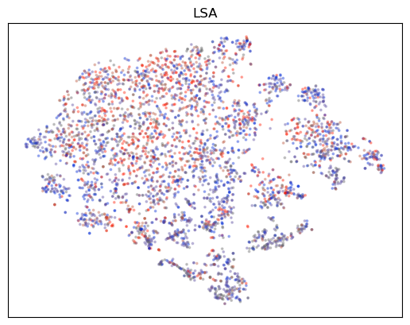

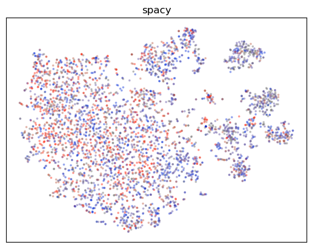

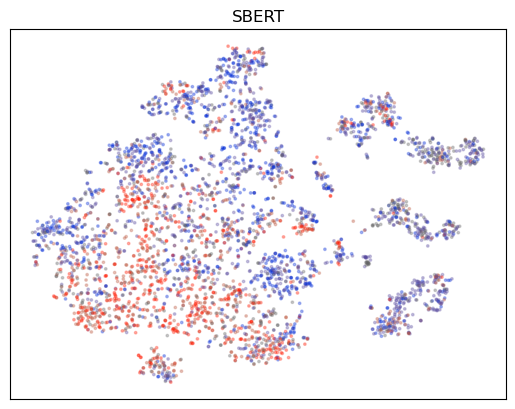

```python
plot_projection(TSNE(2, perplexity=25).fit_transform(lsa_vectors), title="LSA")
plt.show()
plot_projection(TSNE(2, perplexity=25).fit_transform(spacy_vectors), title="spacy")
plt.show()
plot_projection(TSNE(2, perplexity=25).fit_transform(sbert_vectors), title="SBERT")
plt.show()
```

Next let's compare the results for SBERT vectors with different values for perlexity. Which looks most informative?

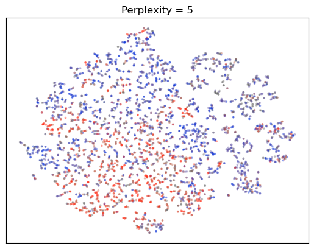

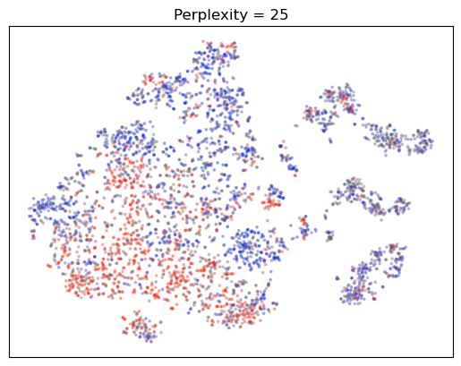

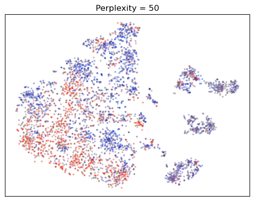

```python
plot_projection(TSNE(2, perplexity=5).fit_transform(sbert_vectors), title="Perplexity = 5")
plt.show()
plot_projection(TSNE(2, perplexity=25).fit_transform(sbert_vectors), title="Perplexity = 25")
plt.show()
plot_projection(TSNE(2, perplexity=50).fit_transform(sbert_vectors), title="Perplexity = 50")
plt.show()
```

If we like the looks of one of these, let's save it for later use.

```python
projection = TSNE(2, perplexity=25).fit_transform(sbert_vectors)
sents['x'] = projection[:,0]
sents['y'] = projection[:,1]
```

### HDBSCAN

We can see some patterns in the data just by eyeballing 2d or 3d t-SNE plots, but we can find more subtle patterns by applying a clustering method to the data in higher dimensions. For semantic vectors, the hierarchical density-based clustering algorithm HDBSCAN has been shown to give good results.

[**HBDSCAN**](https://scikit-learn.org/stable/modules/generated/sklearn.cluster.HDBSCAN.html#sklearn-cluster-hdbscan) has a few important hyperparameters: the most important is probably `min_cluster_size`, which sets the bottom limit for how small a cluster can be and still count as a cluster.

See also:

- [scikit-learn user's guide](https://scikit-learn.org/stable/modules/clustering.html#hdbscan)
- [Müller & Guido](https://learning.oreilly.com/library/view/introduction-to-machine/9781449369880/) section 3.5.3

```python
clusters = HDBSCAN(min_cluster_size=10).fit_predict(sbert_vectors)
```

```python
print(Counter(clusters))
```

```
Counter({-1: 3180, 3: 323, 8: 214, 10: 110, 7: 94, 6: 62, 4: 59, 5: 55, 1: 51, 0: 19, 9: 16, 2: 15, 11: 12})
```

Another way to evaluate the results is to re-draw our t-SNE plot using color-coded clusters rather then star ratings

```python
def plot_clusters(proj, clusters, title=None):
    alpha = [0.02 if c == -1 else 1.0 for c in clusters]
    plt.scatter(proj[:, 0], proj[:, 1], s=3, alpha=alpha, c=clusters, cmap=cc.m_glasbey)
    plt.tick_params(left=False, bottom=False, labelleft=False, labelbottom=False)
    if title:
        plt.title(title)
```

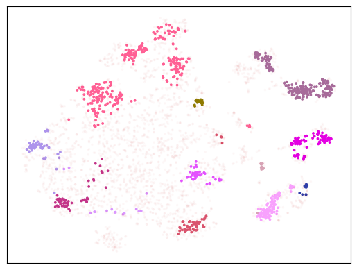

```python
plot_clusters(projection, clusters)
```

Once we have a clustering solution we like, add it to our sentences.

```python
sents['cluster'] = clusters
```

## Interpretation

Now we have to somehow make sense of all this!

### Cluster keywords

To assign interpretions or labels to clusters, we can use keyword analysis to find words that are frequent in sentences in a cluster and/or that are associated with a cluster.

Start with freqeuncy:

```python
for c in sorted(sents['cluster'].unique()):
    if c != -1:
        freq = Counter(concat(sents.query(f'cluster=={c}')['tokenized']))
        print(c, ' '.join(f'{w} ({f})' for w,f in freq.most_common(5)))
```

```
0 . (13) location (12) the (11) is (7) ! (7)
1 . (50) the (50) and (37) staff (34) friendly (25)
2 the (20) , (17) . (14) to (12) it (10)
3 , (363) the (327) . (285) and (235) hotel (208)
4 the (83) . (57) , (45) and (43) room (30)
5 . (55) and (53) the (52) was (51) room (37)
6 . (45) ! (16) i (8) not (6) stay (5)
7 , (82) . (79) de (56) et (38) " (34)
8 , (203) . (181) e (125) la (116) " (79)
9 , (21) в (12) . (11) ! (8) - (6)
10 . (104) , (37) die (27) und (21) zimmer (18)
11 " (12) . (12) lage (7) hotel (7) , (6)
```

That's not very helpful! Now try PMI:

```python
vocab = Counter(concat(sents['tokenized']))

for c in sorted(sents['cluster'].unique()):
    if c != -1:
        freq = Counter(concat(sents.query(f'cluster=={c}')['tokenized']))
        mi = Counter()
        for w in freq:
            if freq[w] > 5:
                mi[w] = (np.log2(freq[w]) + np.log2(vocab.total())
                         - np.log2(vocab[w]) - np.log2(freq.total()))
        print(c, ' '.join(f'{w} ({f:5.3})' for w,f in mi.most_common(5)))
```

```
0 location ( 5.46) is ( 3.08) ! (  3.0) . ( 1.37) the ( 1.33)
1 friendly (  5.3) helpful ( 4.63) staff ( 4.61) elizabeth ( 4.05) were ( 2.26)
2 out ( 3.03) it ( 2.07) but (  1.8) that ( 1.57) not ( 1.14)
3 fantastic location (  3.3) minute walk ( 3.27) rockefeller ( 3.27) rockefeller center (  3.2) 5th avenue ( 3.13)
4 dirty ( 4.17) shower ( 4.12) bathroom (  4.0) room ( 2.07) rooms ( 1.97)
5 nicely ( 5.66) spacious ( 5.34) clean ( 4.53) comfortable ( 4.38) large ( 4.26)
6 ! ( 2.92) . (  1.9) not ( 1.53) i (  1.1)
7 était ( 5.35) été ( 5.29) je ( 5.23) hôtel ( 4.97) cet ( 4.88)
8 pulizia ( 4.13) consiglio ( 4.13) tutti ( 4.13) nostra ( 4.13) bagno ( 4.13)
9 в (  8.0) - ( 1.87) ! ( 1.68) , (0.871) . (-0.383)
10 sauber ( 5.54) som ( 5.44) war ( 5.43) zimmer ( 5.37) var ( 5.37)
11 lage ( 6.57) " ( 2.14) hotel ( 1.95) . (0.552) , (-0.127)
```

### Topics

Another approach (used by [BERTopic](https://maartengr.github.io/BERTopic/algorithm/algorithm.html)) treats sentence cluster labels a bit like the topics produced by LDA. They can then be analyzed using any of the methods you might use for interpreting the results of an LDA model.

```python
sents.groupby("cluster")["rating"].agg(["mean", "std", "count"])
```

| cluster | mean | std | count |
| --- | --- | --- | --- |
| -1 | 3.172642 | 1.368111 | 3180 |
| 0 | 4.263158 | 0.871914 | 19 |
| 1 | 4.372549 | 0.747283 | 51 |
| 2 | 2.133333 | 1.060099 | 15 |
| 3 | 4.012384 | 1.051397 | 323 |
| 4 | 1.932203 | 1.048224 | 59 |
| 5 | 4.109091 | 0.975111 | 55 |
| 6 | 2.854839 | 1.458123 | 62 |
| 7 | 3.627660 | 0.829354 | 94 |
| 8 | 3.359813 | 1.042060 | 214 |
| 9 | 3.312500 | 0.478714 | 16 |
| 10 | 3.672727 | 1.041427 | 110 |
| 11 | 3.416667 | 1.083625 | 12 |

```python
sents.query('cluster==7')
```

|  | text | review_id | rating | tokenized | x | y | cluster |
| --- | --- | --- | --- | --- | --- | --- | --- |
| 10 | Hotel bien placé mais c'est son seul avantage.... | 126843 | 2.0 | [hotel, bien, placé, mais, c'est, son, seul, a... | 58.442810 | 1.051967 | 7 |
| 73 | “Séjour OK” Très bien placé : Proche Times Squ... | 125010 | 2.0 | [", séjour, ok, ", très, bien, placé, :, proch... | 61.208839 | -7.151534 | 7 |
| 93 | “Parking central NY hôtel: bien mais peut mieu... | 119539 | 3.0 | [", parking, central, ny, hôtel, :, bien, mais... | 56.758289 | -6.704250 | 7 |
| 126 | Je recommande cet hôtel pour des voyageurs à l... | 111557 | 4.0 | [je, recommande, cet, hôtel, pour, des, voyage... | 57.846413 | 2.042867 | 7 |
| 129 | C'est central (proche de Broadway, de la 5ème ... | 128837 | 3.0 | [c'est, central, (, proche, de, broadway, ,, d... | 61.703632 | -7.245779 | 7 |
| ... | ... | ... | ... | ... | ... | ... | ... |
| 4043 | “Hôtel parfait” Hôtel idéalement situé, très p... | 126080 | 4.0 | [", hôtel, parfait, ", hôtel, idéalement, situ... | 55.823395 | -0.458143 | 7 |
| 4045 | \nAprès de longues hésitations pour choisir no... | 126080 | 4.0 | [après, de, longues, hésitations, pour, choisi... | 57.615326 | 2.237499 | 7 |
| 4049 | \nBien entendu, le prix est très élevé par rap... | 126080 | 4.0 | [bien, entendu, ,, le, prix, est, très, élevé,... | 58.327980 | 2.458598 | 7 |
| 4053 | Pour la consigne nous avions 8 bagages (nous é... | 129133 | 4.0 | [pour, la, consigne, nous, avions, 8, bagages,... | 67.724564 | -0.314761 | 7 |
| 4174 | “pas emballe” hôtel bien situé. | 125329 | 3.0 | [", pas, emballe, ", hôtel, bien, situé, .] | 57.270561 | 0.521854 | 7 |

94 rows × 7 columns

```python
hotel.loc[60357]['review_text']
```

```
'“Visited again: it\'s like watching a place die ...” Wow, how things can change in the hotel business! The hotel staff who used to be friendly, warm and welcoming have become distant, cold and arrogant. I\'m talking about the front desk staff. Not at all helpful. Not at all concerned about the qual…
```

And, as with LDA topics, we can represent a whole review via the combination of the cluster labels of its sentences:

```python
hotel['clusters'] = sents.groupby('review_id')['cluster'].apply(list)
hotel
```

|  | title | text | date_stayed | offering_id | date | service | cleanliness | overall | value | location | sleep_quality | rooms | check_in_front_desk | business_service_(e_g_internet_access) | review_text | clusters |
| --- | --- | --- | --- | --- | --- | --- | --- | --- | --- | --- | --- | --- | --- | --- | --- | --- |
| 108308 | “ΑΞΙΖΕ ΤΑ ΧΡΗΜΑΤΑ ΤΟΥ ΣΕ ΚΑΘΕ ΠΕΡΙΠΤΩΣΗ!” | Η τοποθεσία του ξενοδοχείου εξαιρετική!!!! Κον... | August 2012 | 93520 | 2012-09-14 | 4.0 | 4.0 | 4.0 | 4.0 | 5.0 | 5.0 | 4.0 | NaN | NaN | “ΑΞΙΖΕ ΤΑ ΧΡΗΜΑΤΑ ΤΟΥ ΣΕ ΚΑΘΕ ΠΕΡΙΠΤΩΣΗ!” Η το... | [-1, 9, -1, -1, 9, -1, -1, 9, 9] |
| 126843 | “Hotel bien placé .” | Hotel bien placé mais c'est son seul avantage.... | October 2008 | 93520 | 2008-11-04 | 1.0 | 3.0 | 2.0 | 2.0 | 5.0 | NaN | 2.0 | 1.0 | 1.0 | “Hotel bien placé .” Hotel bien placé mais c'e... | [-1, 7, -1, -1, 6, -1] |
| 64445 | “Better than expected after reading some revie... | This hotel was perfect. Close to everything, c... | January 2012 | 93520 | 2012-01-13 | 4.0 | 3.0 | 4.0 | 5.0 | 5.0 | NaN | 5.0 | NaN | NaN | “Better than expected after reading some revie... | [-1, -1, -1, -1, 6, -1, -1, -1] |
| 100496 | “Worst Stay Ever” | This June was my fourth stay at the Park Centr... | June 2006 | 93520 | 2006-06-06 | 2.0 | 1.0 | 1.0 | 1.0 | NaN | NaN | 2.0 | NaN | NaN | “Worst Stay Ever” This June was my fourth stay... | [-1, -1, -1, -1, -1, -1, -1, -1, -1, -1, -1, -... |
| 68633 | “HATED IT - Definitely NOT 4 stars!” | This hotel would have been great if it were li... | August 2011 | 93520 | 2011-08-23 | 1.0 | 2.0 | 1.0 | 1.0 | NaN | 2.0 | NaN | NaN | NaN | “HATED IT - Definitely NOT 4 stars!” This hote... | [-1, 3, -1, -1, -1, -1, -1, -1, -1, -1] |
| ... | ... | ... | ... | ... | ... | ... | ... | ... | ... | ... | ... | ... | ... | ... | ... | ... |
| 125329 | “pas emballe” | hôtel bien situé. Acceuil d'hôtel de chaine , ... | None | 93520 | 2009-03-23 | NaN | NaN | 3.0 | NaN | NaN | NaN | NaN | NaN | NaN | “pas emballe” hôtel bien situé. Acceuil d'hôte... | [7, -1] |
| 72464 | “Highly Recocomend” | Excelent location, very close to Time Square a... | October 2010 | 93520 | 2010-10-13 | 4.0 | 5.0 | 5.0 | 2.0 | 5.0 | 4.0 | 5.0 | NaN | NaN | “Highly Recocomend” Excelent location, very cl... | [-1, -1, -1, -1] |
| 122589 | “BUON PUNTO DI PARTENZA PER VISITARE NEW YORK” | hotel collocato in luogo strategico per la vis... | None | 93520 | 2009-10-04 | NaN | NaN | 5.0 | NaN | NaN | NaN | NaN | NaN | NaN | “BUON PUNTO DI PARTENZA PER VISITARE NEW YORK”... | [-1, 8, 8, 8, 8] |
| 94378 | “There is ZERO customer service at this hotel!” | Our company had booked this hotel on a recent ... | March 2009 | 93520 | 2009-04-07 | 1.0 | 3.0 | 2.0 | 1.0 | 3.0 | NaN | 3.0 | NaN | NaN | “There is ZERO customer service at this hotel!... | [-1, -1, -1, -1, -1, -1, -1, -1, -1, -1, -1, -1] |
| 74878 | “Loved It!!! Our second stay” | My first time at this hotel was in July 2008. ... | July 2009 | 93520 | 2010-03-03 | 4.0 | 4.0 | 4.0 | 5.0 | 5.0 | 4.0 | 4.0 | NaN | NaN | “Loved It!!! Our second stay” My first time at... | [-1, 3, -1, -1, -1, -1, -1, -1, 3, 6, -1, -1, -1] |

500 rows × 16 columns

### Interactive exploration

The last method we'll consider uses [Bokeh](https://bokeh.org/) to create an interative visualization.

```python
tooltips = [("text", "@sent")]
tooltips = """
<div style="width:400px;margin: 0px 0px 5px 0px;">@rating★ "@text"</div>
"""

palette = list(reversed(cc.CET_D8))
rating_cmap = linear_cmap("rating", palette=palette, low=1, high=5)

p = figure(
    x_axis_type=None,
    y_axis_type=None,
    tools="pan,wheel_zoom,box_zoom,zoom_in,zoom_out,hover,save,reset,help",
    tooltips=tooltips,
    title="Ratings"
)
scatter = p.scatter(
    "x",
    "y",
    source=sents,
    fill_alpha=0.8,
    alpha=0.01,
    radius=0.6,
    fill_color=rating_cmap,
)

show(p)
```

```python
tooltips = [("text", "@sent")]
tooltips = """
<div style="width:400px;margin: 0px 0px 5px 0px;">@rating★ (@cluster) "@text"</div>
"""

cmap = linear_cmap("cluster", palette=cc.glasbey, low=0, high=sents['cluster'].max())

p = figure(
    x_axis_type=None,
    y_axis_type=None,
    tools="pan,wheel_zoom,box_zoom,zoom_in,zoom_out,hover,save,reset,help",
    tooltips=tooltips,
    title="Clusters"
)
p.scatter(
    "x",
    "y",
    source=sents.query('cluster!=-1'),
    fill_alpha=0.8,
    alpha=0.01,
    radius=0.6,
    fill_color=cmap,
)
show(p)
```